# Final Project - STAT 1500

Gracian Anton, Shael Kotecha, Felipe De Oliveira, Paul Hoang

2026-08-07

## Background

Predicting house prices aids in real estimation of homes, approximation of net equity for particular individuals, and areas of prospective relocation for buyers. Statistical modelling helps us understand housing markets by observing which attributes (e.g. age, area, number of rooms, etc) are able to best predict a house price. It also helps us determine which attributes should be included and excluded when predicting a house price based on their correlation to the target variable.

## Literature Review

Housing prices are influenced by many different factors, including characteristics of the property itself, location, and changes in the overall housing market. Since multiple factors can affect house prices at the same time, previous research has commonly used regression methods to understand the relationship between these variables. Multiple regression models are useful in housing research because they allow researchers to estimate the effect of individual factors. This approach helps provide a better understanding of which features of a property have the strongest relationship with its selling price.

Morel (2022) examined changes in housing prices across major Canadian cities and analyzed how structural and neighbourhood characteristics influenced property values. The study considered factors such as house size, age, and location, including the distance of properties from downtown areas. One of the main findings was that during the COVID-19 pandemic, the price advantage of homes located closer to downtown areas decreased. As remote work became more common, many buyers started to prefer larger suburban homes with more space rather than smaller properties in urban locations. This study demonstrates that housing prices are affected by more than just physical characteristics of a house, as market conditions and changes in buyer preferences can also influence the importance of different predictors. It also supports the use of regression models because they allow researchers to separate the effects of different housing and location factors.

Similarly, Schaefer and Panagiotoglou (2024) used a hedonic pricing model to analyze housing prices in Montreal. Hedonic pricing models are commonly used in real estate research because they estimate how different characteristics contribute to the overall value of a property. Their study included internal housing features, such as bedrooms, bathrooms, and unit size, along with external factors related to neighbourhood characteristics. By including multiple variables in their model, the researchers were able to measure the effect of a specific location-based factor while keeping other housing characteristics constant. This approach is closely related to the method used in this project, where multiple regression is used to determine the individual effects of variables such as Overall Quality, Gr Liv Area, and Neighborhood on SalePrice.

Another important source for this project is De Cock (2011), which introduced the Ames Housing dataset used in this analysis. The paper describes the dataset as an alternative to the Boston Housing dataset and provides detailed information about residential properties in Ames, Iowa. The dataset includes many variables related to housing characteristics, including living area, basement size, garage features, construction quality, year built, and neighbourhood information. While De Cock (2011) does not directly investigate which factors affect housing prices, it provides a valuable dataset for applying regression techniques. The large number of available predictors makes the dataset useful for studying how different property characteristics are associated with variations in sale prices.

Overall, previous research shows that factors such as house size, quality, and location are important predictors of housing prices. Studies have consistently found that structural characteristics and neighbourhood differences can significantly affect property values. These findings support the selection of variables used in this project, including Overall Quality, Gr Liv Area, Total Basement SF, Garage characteristics, Year Built, and Neighborhood. By applying multiple regression analysis to the Ames Housing dataset, this project builds on previous research by examining which factors remain significant when multiple housing characteristics are considered together.

```r
library(tidyverse)
df <- read.csv("AmesHousing.csv")
print("Finished loading data")
```

```
## [1] "Finished loading data"
```

### Data Cleaning

This data cleaning step selects the relevant columns for predicting the house price, removes any rows which have null data values, and converts the categorical attribute (Neighborhood) to a numerical attribute for model training.

```r
df <- df %>%
    select(Overall.Qual,Gr.Liv.Area,Total.Bsmt.SF,Garage.Cars,Year.Built,Full.Bath, Bedroom.AbvGr
           ,TotRms.AbvGrd,Garage.Area, Neighborhood, SalePrice) %>%
    filter(if_all(everything(), ~!is.na(.))) %>%
    mutate(Neighborhood = case_when(
      Neighborhood == "NAmes"     ~ 0,
      Neighborhood == "Gilbert"   ~ 1,
      Neighborhood == "StoneBr"   ~ 2,
      Neighborhood == "NWAmes"    ~ 3,
      Neighborhood == "Somerst"   ~ 4,
      Neighborhood == "BrDale"    ~ 5,
      Neighborhood == "NPkVill"   ~ 6,
      Neighborhood == "NridgHt"   ~ 7,
      Neighborhood == "Blmngtn"   ~ 8,
      Neighborhood == "NoRidge"   ~ 9,
      Neighborhood == "SawyerW"   ~ 10,
      Neighborhood == "Sawyer"    ~ 11,
      Neighborhood == "Greens"    ~ 12,
      Neighborhood == "BrkSide"   ~ 13,
      Neighborhood == "OldTown"   ~ 14,
      Neighborhood == "IDOTRR"    ~ 15,
      Neighborhood == "ClearCr"   ~ 16,
      Neighborhood == "SWISU"     ~ 17,
      Neighborhood == "Edwards"   ~ 18,
      Neighborhood == "CollgCr"   ~ 19,
      Neighborhood == "Crawfor"   ~ 20,
      Neighborhood == "Blueste"   ~ 21,
      Neighborhood == "Mitchel"   ~ 22,
      Neighborhood == "Timber"    ~ 23,
      Neighborhood == "MeadowV"   ~ 24,
      Neighborhood == "Veenker"   ~ 25,
      Neighborhood == "GrnHill"   ~ 26,
      Neighborhood == "Landmrk"   ~ 27
    )) %>%
    mutate(SalePrice = log(SalePrice))
head(df,10)
```

```
##    Overall.Qual Gr.Liv.Area Total.Bsmt.SF Garage.Cars Year.Built Full.Bath
## 1             6        1656          1080           2       1960         1
## 2             5         896           882           1       1961         1
## 3             6        1329          1329           1       1958         1
## 4             7        2110          2110           2       1968         2
## 5             5        1629           928           2       1997         2
## 6             6        1604           926           2       1998         2
## 7             8        1338          1338           2       2001         2
## 8             8        1280          1280           2       1992         2
## 9             8        1616          1595           2       1995         2
## 10            7        1804           994           2       1999         2
##    Bedroom.AbvGr TotRms.AbvGrd Garage.Area Neighborhood SalePrice
## 1              3             7         528            0  12.27839
## 2              2             5         730            0  11.56172
## 3              3             6         312            0  12.05525
## 4              3             8         522            0  12.40492
## 5              3             6         482            1  12.15425
## 6              3             7         470            1  12.18332
## 7              2             6         582            2  12.27139
## 8              2             5         506            2  12.16264
## 9              2             5         608            2  12.37370
## 10             3             7         442            1  12.14950
```

```r
print("Finished cleaning data")
```

```
## [1] "Finished cleaning data"
```

## Exploratory Data Analysis

### Numerical Analysis

This numerical analyis analyzes the mean, median, standard deviation, minimum, and maximum of each column in the dataset.

```r
statistics <- df %>%
  summarize(
    across(everything(), list(
      Mean = ~ mean(.),
      Median = ~ median(.),
      StandardDeviation = ~ sd(.),
      Minimum = ~ min(.),
      Maximum = ~ max(.)))
  )

statistics
```

```
##   Overall.Qual_Mean Overall.Qual_Median Overall.Qual_StandardDeviation
## 1           6.09597                   6                       1.410831
##   Overall.Qual_Minimum Overall.Qual_Maximum Gr.Liv.Area_Mean Gr.Liv.Area_Median
## 1                    1                   10         1499.784               1442
##   Gr.Liv.Area_StandardDeviation Gr.Liv.Area_Minimum Gr.Liv.Area_Maximum
## 1                       505.522                 334                5642
##   Total.Bsmt.SF_Mean Total.Bsmt.SF_Median Total.Bsmt.SF_StandardDeviation
## 1            1051.68                  990                        440.6759
##   Total.Bsmt.SF_Minimum Total.Bsmt.SF_Maximum Garage.Cars_Mean
## 1                     0                  6110         1.767077
##   Garage.Cars_Median Garage.Cars_StandardDeviation Garage.Cars_Minimum
## 1                  2                     0.7605642                   0
##   Garage.Cars_Maximum Year.Built_Mean Year.Built_Median
## 1                   5        1971.381              1973
##   Year.Built_StandardDeviation Year.Built_Minimum Year.Built_Maximum
## 1                     30.23884               1872               2010
##   Full.Bath_Mean Full.Bath_Median Full.Bath_StandardDeviation Full.Bath_Minimum
## 1       1.566598                2                   0.5529723                 0
##   Full.Bath_Maximum Bedroom.AbvGr_Mean Bedroom.AbvGr_Median
## 1                 4           2.854508                    3
##   Bedroom.AbvGr_StandardDeviation Bedroom.AbvGr_Minimum Bedroom.AbvGr_Maximum
## 1                       0.8278589                     0                     8
##   TotRms.AbvGrd_Mean TotRms.AbvGrd_Median TotRms.AbvGrd_StandardDeviation
## 1           6.443989                    6                        1.572832
##   TotRms.AbvGrd_Minimum TotRms.AbvGrd_Maximum Garage.Area_Mean
## 1                     2                    15         472.8856
##   Garage.Area_Median Garage.Area_StandardDeviation Garage.Area_Minimum
## 1                480                      215.0537                   0
##   Garage.Area_Maximum Neighborhood_Mean Neighborhood_Median
## 1                1488          10.55704                  11
##   Neighborhood_StandardDeviation Neighborhood_Minimum Neighborhood_Maximum
## 1                       7.723052                    0                   27
##   SalePrice_Mean SalePrice_Median SalePrice_StandardDeviation SalePrice_Minimum
## 1       12.02126         11.98293                   0.4074903          9.456341
##   SalePrice_Maximum
## 1          13.53447
```

### Visualization

This visualization compares different attributes with each other graphically and performs a correlation analysis of the age of the house and the housing price.

[figure not shown]

```r
df %>%
  ggplot(mapping = aes(x = SalePrice)) + geom_histogram(bins = 30, fill='skyblue', color='black') + labs(title='Figure 1: Distribution of   House Prices', x = "# of homes", y = 'House Price')
```

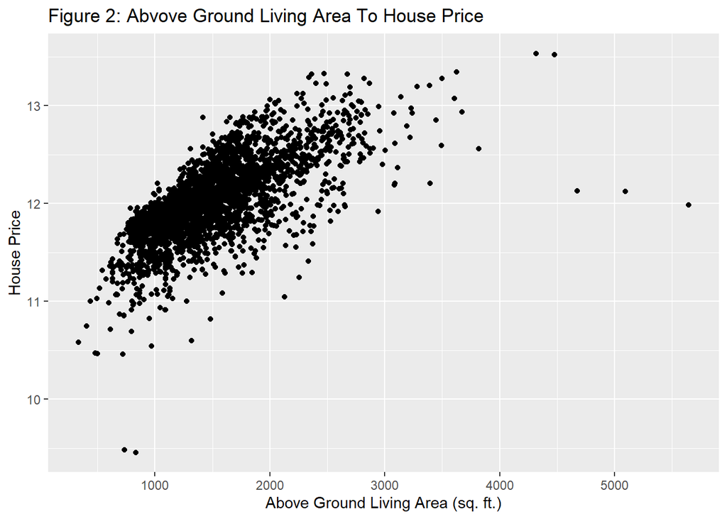

```r
df %>%
  ggplot(mapping = aes(x=Gr.Liv.Area, y=SalePrice)) + geom_point() + labs(title='Figure 2: Abvove Ground Living Area To House Price', x = 'Above Ground Living Area (sq. ft.)', y='House Price')
```

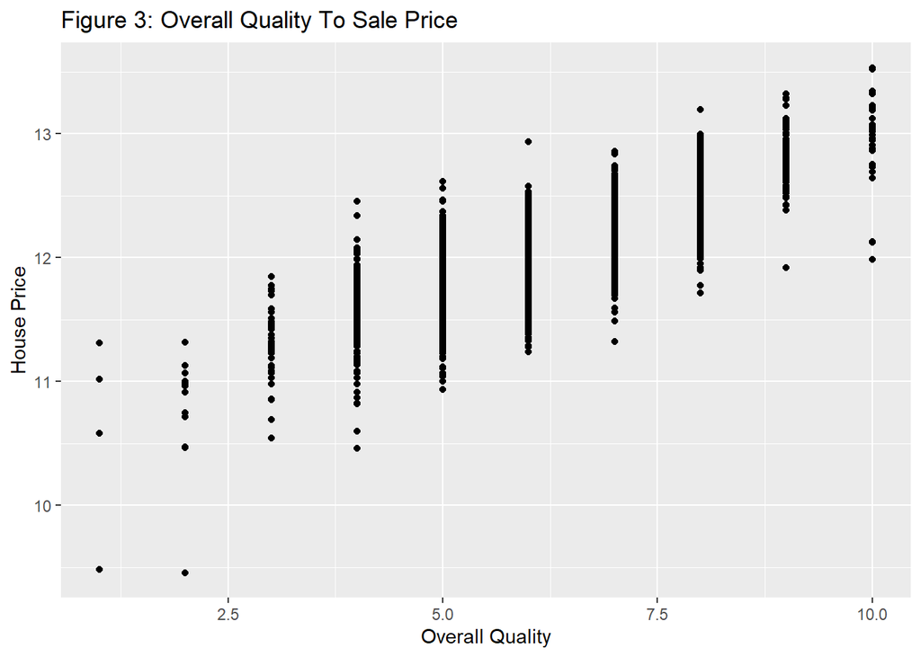

```r
df %>%
  ggplot(mapping = aes(x=Overall.Qual, y = SalePrice)) + geom_point() + labs(title='Figure 3: Overall Quality To Sale Price', x='Overall Quality', y='House Price')
```

```r
correlationDf = df[c('Year.Built','SalePrice')]

cor(correlationDf, use='complete.obs')
```

```
##            Year.Built SalePrice
## Year.Built  1.0000000 0.6155309
## SalePrice   0.6155309 1.0000000
```

### Correlation Matrix

```r
library(reshape2)
numeric_df <- df %>% select(where(is.numeric))
cor_matrix <- cor(numeric_df, use = "complete.obs")
round(cor_matrix, 2)
```

```
##               Overall.Qual Gr.Liv.Area Total.Bsmt.SF Garage.Cars Year.Built
## Overall.Qual          1.00        0.57          0.55        0.60       0.60
## Gr.Liv.Area           0.57        1.00          0.44        0.49       0.24
## Total.Bsmt.SF         0.55        0.44          1.00        0.44       0.41
## Garage.Cars           0.60        0.49          0.44        1.00       0.54
## Year.Built            0.60        0.24          0.41        0.54       1.00
## Full.Bath             0.52        0.63          0.33        0.48       0.47
## Bedroom.AbvGr         0.06        0.52          0.05        0.09      -0.06
## TotRms.AbvGrd         0.38        0.81          0.28        0.36       0.11
## Garage.Area           0.56        0.48          0.49        0.89       0.48
## Neighborhood         -0.11       -0.03         -0.07       -0.12      -0.14
## SalePrice             0.83        0.70          0.63        0.68       0.62
##               Full.Bath Bedroom.AbvGr TotRms.AbvGrd Garage.Area Neighborhood
## Overall.Qual       0.52          0.06          0.38        0.56        -0.11
## Gr.Liv.Area        0.63          0.52          0.81        0.48        -0.03
## Total.Bsmt.SF      0.33          0.05          0.28        0.49        -0.07
## Garage.Cars        0.48          0.09          0.36        0.89        -0.12
## Year.Built         0.47         -0.06          0.11        0.48        -0.14
## Full.Bath          1.00          0.36          0.53        0.41        -0.06
## Bedroom.AbvGr      0.36          1.00          0.67        0.07        -0.05
## TotRms.AbvGrd      0.53          0.67          1.00        0.33        -0.05
## Garage.Area        0.41          0.07          0.33        1.00        -0.09
## Neighborhood      -0.06         -0.05         -0.05       -0.09         1.00
## SalePrice          0.58          0.18          0.49        0.65        -0.11
##               SalePrice
## Overall.Qual       0.83
## Gr.Liv.Area        0.70
## Total.Bsmt.SF      0.63
## Garage.Cars        0.68
## Year.Built         0.62
## Full.Bath          0.58
## Bedroom.AbvGr      0.18
## TotRms.AbvGrd      0.49
## Garage.Area        0.65
## Neighborhood      -0.11
## SalePrice          1.00
```

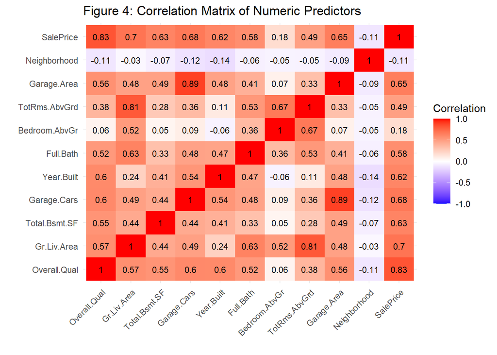

```r
cor_melt <- melt(cor_matrix)

ggplot(cor_melt, aes(x = Var1, y = Var2, fill = value)) +
  geom_tile() +
  geom_text(aes(label = round(value, 2)), size = 3) +
  scale_fill_gradient2(low = "blue", high = "red", mid = "white", midpoint = 0,
                        limit = c(-1,1), name = "Correlation") +
  theme_minimal() +
  theme(axis.text.x = element_text(angle = 45, hjust = 1)) +
  labs(title = "Figure 4: Correlation Matrix of Numeric Predictors", x = "", y = "")
```

```r
model <- lm(SalePrice ~., data = df)

summary <- summary(model)

coefficients <- summary$coefficients[, "Estimate"]
names <- names(coefficients)

# paste0() concatenates the character and numeric with 0 spaces in between  and converts the numeric to a character
regression_equation <- paste0("Sale Price = ", paste0(coefficients[1], " + "))
for (i in 2:length(names)){
  regression_equation = paste0(
    regression_equation, paste0(
      coefficients[names[i]],
        paste0(
          "x",  paste0(i, paste0(ifelse(i == length(names), "", " + ")))
        )
    )
  )
}

print("Regression Equation:")
```

```
## [1] "Regression Equation:"
```

```r
regression_equation
```

```
## [1] "Sale Price = 5.81446734608852 + 0.110159303237987x2 + 0.00026061351919112x3 + 0.000129865874786782x4 + 0.054848394663145x5 + 0.00249726051848117x6 + -0.011905372351289x7 + -0.00376440157731806x8 + -0.00275392927457331x9 + 7.86554377081323e-05x10 + -0.000209123096672127x11"
```

```r
print("Estimated Coefficients:")
```

```
## [1] "Estimated Coefficients:"
```

```r
coefficients
```

```
##   (Intercept)  Overall.Qual   Gr.Liv.Area Total.Bsmt.SF   Garage.Cars
##  5.814467e+00  1.101593e-01  2.606135e-04  1.298659e-04  5.484839e-02
##    Year.Built     Full.Bath Bedroom.AbvGr TotRms.AbvGrd   Garage.Area
##  2.497261e-03 -1.190537e-02 -3.764402e-03 -2.753929e-03  7.865544e-05
##  Neighborhood
## -2.091231e-04
```

```r
print("T Values:")
```

```
## [1] "T Values:"
```

```r
summary$coefficients[,"t value"]
```

```
##   (Intercept)  Overall.Qual   Gr.Liv.Area Total.Bsmt.SF   Garage.Cars
##    20.2159953    30.2551378    19.4789649    14.1345846     5.5374669
##    Year.Built     Full.Bath Bedroom.AbvGr TotRms.AbvGrd   Garage.Area
##    16.5929846    -1.4169163    -0.6804996    -0.6875703     2.3263275
##  Neighborhood
##    -0.4988615
```

```r
print("P Values:")
```

```
## [1] "P Values:"
```

```r
summary$coefficients[,"Pr(>|t|)"]
```

```
##   (Intercept)  Overall.Qual   Gr.Liv.Area Total.Bsmt.SF   Garage.Cars
##  3.711302e-85 3.998282e-175  1.515499e-79  6.337328e-44  3.341646e-08
##    Year.Built     Full.Bath Bedroom.AbvGr TotRms.AbvGrd   Garage.Area
##  3.708135e-59  1.566142e-01  4.962422e-01  4.917781e-01  2.006927e-02
##  Neighborhood
##  6.179146e-01
```

```r
print("Standard Error:")
```

```
## [1] "Standard Error:"
```

```r
summary$coefficients[,"Std. Error"]
```

```
##   (Intercept)  Overall.Qual   Gr.Liv.Area Total.Bsmt.SF   Garage.Cars
##  2.876172e-01  3.641011e-03  1.337923e-05  9.187810e-06  9.904961e-03
##    Year.Built     Full.Bath Bedroom.AbvGr TotRms.AbvGrd   Garage.Area
##  1.505010e-04  8.402311e-03  5.531820e-03  4.005306e-03  3.381099e-05
##  Neighborhood
##  4.192007e-04
```

## Model Fit Evaluation and Interpretation

```r
r_squared <- summary$r.squared
adj_r_squared <- summary$adj.r.squared

cat("R-squared:", round(r_squared, 4), "\n")
```

```
## R-squared: 0.8223
```

```r
cat("Adjusted R-squared:", round(adj_r_squared, 4), "\n")
```

```
## Adjusted R-squared: 0.8217
```

```r
f_stat <- summary$fstatistic
f_value <- f_stat["value"]
f_df1 <- unname(f_stat["numdf"])
f_df2 <- unname(f_stat["dendf"])
f_p_value <- pf(f_value, f_df1, f_df2, lower.tail = FALSE)

cat("F-statistic:", round(f_value, 2), "on", f_df1, "and", f_df2, "DF\n")
```

```
## F-statistic: 1349.85 on 10 and 2917 DF
```

```r
cat("Overall model p-value:", format.pval(f_p_value, digits = 3), "\n")
```

```
## Overall model p-value: <2e-16
```

```r
anova_table <- anova(model)
anova_table
```

```
## Analysis of Variance Table
##
## Response: SalePrice
##                 Df Sum Sq Mean Sq    F value  Pr(>F)
## Overall.Qual     1 331.22  331.22 11187.1761 < 2e-16 ***
## Gr.Liv.Area      1  36.41   36.41  1229.6103 < 2e-16 ***
## Total.Bsmt.SF    1  12.02   12.02   405.8782 < 2e-16 ***
## Garage.Cars      1  10.93   10.93   369.0302 < 2e-16 ***
## Year.Built       1   8.74    8.74   295.2177 < 2e-16 ***
## Full.Bath        1   0.11    0.11     3.8303 0.05043 .
## Bedroom.AbvGr    1   0.04    0.04     1.5128 0.21881
## TotRms.AbvGrd    1   0.02    0.02     0.6832 0.40855
## Garage.Area      1   0.16    0.16     5.3431 0.02087 *
## Neighborhood     1   0.01    0.01     0.2489 0.61791
## Residuals     2917  86.37    0.03
## ---
## Signif. codes:  0 '***' 0.001 '**' 0.01 '*' 0.05 '.' 0.1 ' ' 1
```

```r
## Coefficient interpretation (log-linear model)
## Since SalePrice was log-transformed, each coefficient represents
## the percent change in SalePrice for a one-unit increase in the predictor
pct_change <- (exp(coefficients) - 1) * 100

interpretation_df <- data.frame(
  Variable = names,
  Coefficient = round(coefficients, 5),
  Percent_Change_SalePrice = round(pct_change, 2)
)

print("Percent Change in Sale Price per Unit Increase:")
```

```
## [1] "Percent Change in Sale Price per Unit Increase:"
```

```r
interpretation_df
```

```
##                    Variable Coefficient Percent_Change_SalePrice
## (Intercept)     (Intercept)     5.81447                 33411.29
## Overall.Qual   Overall.Qual     0.11016                    11.65
## Gr.Liv.Area     Gr.Liv.Area     0.00026                     0.03
## Total.Bsmt.SF Total.Bsmt.SF     0.00013                     0.01
## Garage.Cars     Garage.Cars     0.05485                     5.64
## Year.Built       Year.Built     0.00250                     0.25
## Full.Bath         Full.Bath    -0.01191                    -1.18
## Bedroom.AbvGr Bedroom.AbvGr    -0.00376                    -0.38
## TotRms.AbvGrd TotRms.AbvGrd    -0.00275                    -0.28
## Garage.Area     Garage.Area     0.00008                     0.01
## Neighborhood   Neighborhood    -0.00021                    -0.02
```

## Regression Diagnostics

### VIF (Multicollinearity)

```r
library(car)
vif(model)
```

```
##  Overall.Qual   Gr.Liv.Area Total.Bsmt.SF   Garage.Cars    Year.Built
##      2.608643      4.522334      1.620627      5.610450      2.047526
##     Full.Bath Bedroom.AbvGr TotRms.AbvGrd   Garage.Area  Neighborhood
##      2.134149      2.073333      3.923344      5.226731      1.036197
```

Garage.Cars, Garage.Area, and Gr.Liv.Area have the highest VIF values (roughly 4.5-5.6), consistent with the correlations seen in the Figure 4 heatmap (Garage.Area/Garage.Cars = 0.89, Gr.Liv.Area/TotRms.AbvGrd = 0.81). None are high enough to indicate severe multicollinearity (all well under the common rule-of-thumb threshold of 10), but they likely explain why TotRms.AbvGrd, Full.Bath, and Bedroom.AbvGr are not significant below. Neighborhood itself has a very low VIF (~1.04), meaning multicollinearity is not why it comes out non-significant – see the Key Findings discussion below for why.

### Residual Plots

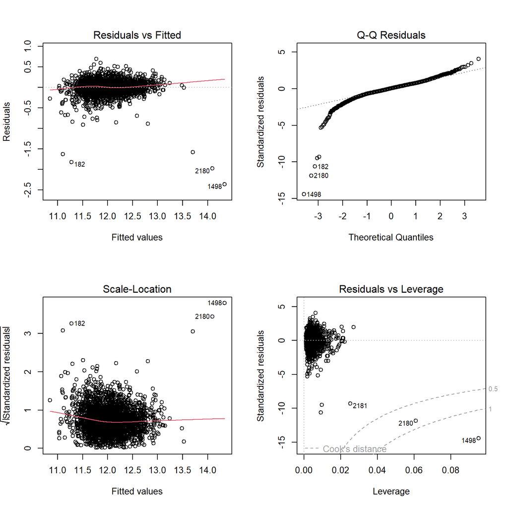

```r
par(mfrow = c(2,2))
plot(model)
```

```r
par(mfrow = c(1,1))
```

Residuals vs Fitted (Figure 5) and Scale-Location (Figure 7) are both reasonably flat, supporting linearity and constant variance. The Normal Q-Q plot (Figure 6) shows a heavier left tail, driven by a few low-priced outlier sales, so normality holds well in the middle of the distribution but not perfectly in the tails.

## Discussion

### Direction of Effects

All significant coefficients had signs matching economic intuition – quality, size, basement area, garage capacity, and more recent construction all raised price, with no implausible effects. Neighborhood’s near-zero, non-significant coefficient is not economically implausible either, but reflects the limitation of its numeric encoding rather than a real absence of location effects.

### Practical Interpretation

Overall quality and living area matter most for estimating a home’s value in Ames, with basement size, garage capacity, and year built as secondary factors. Bedroom/bathroom counts added little once size was already in the model. Neighborhood’s apparent lack of significance here should not be read as “location doesn’t matter” – it is an artifact of treating neighborhood names as if they were ordered numbers, which is a modeling limitation rather than a market fact.

### Expected vs. Actual Results

Overall Qual and Gr Liv Area dominating the model matched our expectations from the literature review. The complete drop-out of Full Bath, Bedroom AbvGr, and TotRms AbvGrd as non-significant was more surprising. The most surprising result was Neighborhood coming out non-significant, since location is consistently found to matter in the housing literature (Morel, 2022; Schaefer & Panagiotoglou, 2024) – this pushed us to recognize that the issue was our encoding choice (numeric codes) rather than a genuine absence of a location effect.

## Conclusion

This project used multiple linear regression to model house sale prices (log-transformed) in Ames, Iowa using overall quality, above-ground living area, total basement square footage, garage capacity, garage area, year built, full bathrooms, bedrooms above grade, total rooms above grade, and neighborhood (encoded numerically). The model achieved R² = 0.822 (Adjusted R² = 0.822), explaining about 82.2% of the variation in log sale price, with a highly significant overall F-test (F = 1349.9 on 10 and 2917 df, p < 2.2e-16). Overall Qual, Gr Liv Area, Year Built, Total Bsmt SF, and Garage Cars/Area were all significant predictors, consistent with the multi-attribute regression approach supported by Morel (2022) and Schaefer and Panagiotoglou (2024), while Full Bath, Bedroom AbvGr, TotRms AbvGrd, and – notably – Neighborhood were not significant in this version of the model.

### Limitations

Only 10 of 80+ available variables were used; some relevant characteristics (lot size, exterior condition, remodel history) were excluded. A more significant limitation is the numeric encoding of Neighborhood: assigning each neighborhood an arbitrary code from 0-27 forces the regression to treat location as if it were a single continuous, linearly-ordered variable, which is not a valid assumption for a categorical attribute with no natural ordering. This is almost certainly why Neighborhood came out statistically non-significant here (p = 0.618) despite location being a well-documented driver of house prices in the broader literature (Morel, 2022; Schaefer & Panagiotoglou, 2024) – the true, likely large effects of individual neighborhoods are being averaged into a single near-zero slope. VIF showed moderate correlation among Garage.Cars, Garage.Area, and Gr.Liv.Area, and residuals showed a few low-priced outliers violating normality in the tails – both are additional reasons to interpret individual coefficients with some caution.

### Future Research

Future work could add more predictors (lot area, exterior quality, remodel age), test neighborhood-by-quality interactions, investigate the flagged outlier sales, or compare against nonlinear/ML approaches, similar to the hedonic modeling frameworks used by Morel (2022) and Schaefer and Panagiotoglou (2024). Given the concerns raised above, re-encoding Neighborhood as a categorical/dummy variable rather than a numeric code would also be a natural next step, since it would let each neighborhood have its own independent effect on price rather than forcing them onto a single arbitrary numeric scale.

## References

Ames Housing Dataset (Iowa State University / Kaggle version). Retrieved from https://www.kaggle.com/datasets/prevek18/ames-housing-dataset

De Cock, D. (2011). Ames, Iowa: Alternative to the Boston Housing Data as an End of Semester Regression Project. *Journal of Statistics Education*, 19(3). https://jse.amstat.org/v19n3/decock.pdf

Morel, L. (2022). Analyzing the house price boom in the suburbs of Canada’s major cities during the pandemic. *Bank of Canada Staff Analytical Note*, No. 2022-7. https://www.bankofcanada.ca/2022/06/staff-analytical-note-2022-7/

Schaefer, M., & Panagiotoglou, D. (2024). Evaluating the effects of supervised consumption sites on housing prices in Montreal, Canada using interrupted time series and hedonic price models. *Drug and Alcohol Dependence Reports*, 11, 100242. https://doi.org/10.1016/j.dadr.2024.100242